# **Kernel-based Combined Classification Rule**

Sothea Has

2022-06-03

# 🔎 How to download & run the codes?

All the source codes of the aggregation methods are available [here](https://github.com/hassothea/AggregationMethods) . To run the codes, you can `clone` the repository directly or simply load the `R script` source file from the repository using [devtools](https://cran.r-project.org/web/packages/devtools/index.html) package in **Rstudio** as follow:

1. Install [devtools](https://cran.r-project.org/web/packages/devtools/index.html) package using command:

   `install.packages("devtools")`
2. Loading the source codes from GitHub repository using `source_url` function by:

   `devtools::source_url("https://raw.githubusercontent.com/hassothea/AggregationMethods/main/KernelAggClassifier.R")`

> **✎ Note**: All codes contained in this `Rmarkdown` are built with recent version of (version $>$ 4.1, available [here](https://cran.r-project.org/bin/windows/base/)) and **Rstudio** (version > `2022.02.2+485`, available [here](https://www.rstudio.com/products/rstudio/download/#download)). Note also that the code chucks are hidden by default.

**To see the codes, you can:**

- click on the top-right Code button of the page, then choose **Show All Code** to show all the codes, or
- simply click on the right-corner Code button at each section to show the codes of that specific section.

# 1 Aggregation method & important packages

## 1.1 Aggregation method

$$g_n({\bf c}(x))=k^*=\text{arg}\max_{1\leq k\leq
N}\sum_{i=1}^{\ell}K_h(d_{\cal H}({\bf c}(x),{\bf
c}(x_i)))\mathbb{1}_{\{y_i=k\}}.$$
Here,

- $K:\mathbb{R}_+\to\mathbb{R}_+$ is a non-increasing kernel function with $K_h(x)=K(x/h)$ for some smoothing parameter $h>0$ to be tuned
- $d_{\cal H}$ is the Hamming distance or the number of different classes among $M$ coordinates.

In words, the predicted class is the class comprising heaviest total weight. Even though the formula of $g_n$ is defined using only data points in $\mathcal{D}_{\ell}$, it does depend on the whole training data $\mathcal{D}_{n}$ as the basic machines $(c_i)_{i=1}^M$ are built using $\mathcal{D}_{k}$.

## 1.2 Important packages

We prepare all the necessary tools for this `Rmarkdown`. `pacman` package allows us to load (if exists) or install (if does not exist) any available packages from [The Comprehensive R Archive Network (CRAN)](https://cran.r-project.org/) of .

```r
# Check if package "pacman" is already installed

lookup_packages <- installed.packages()[,1]
if(!("pacman" %in% lookup_packages))
  install.packages("pacman")


# To be installed or loaded
pacman::p_load(magrittr)
pacman::p_load(tidyverse)

## package for "generateMachines"
pacman::p_load(tree)
pacman::p_load(nnet)
pacman::p_load(e1071)
pacman::p_load(randomForest)
pacman::p_load(FNN)
pacman::p_load(xgboost)
pacman::p_load(adabag)
pacman::p_load(keras)
pacman::p_load(pracma)
pacman::p_load(latex2exp)
pacman::p_load(plotly)
rm(lookup_packages)
```

# 2 Basic machine generator

This section provides functions to generate basic machines (classifiers) to be aggregated.

## 2.1 Function : `setBasicParameter`

This function allows us to set the values of some key parameters of the basic machines.

  This function returns a *list* of all the parameters given in its arguments, to be fed to the `basicMachineParam` argument of function `generateMachines` defined in the next section.

```r
setBasicParameter <- function(k = 10,
                              ntree = 300,
                              mtry = NULL,
                              ker_svm = "radial",
                              deg_svm = 3,
                              mfinal_boost = 50,
                              boostrap = TRUE,
                              eta_xgb = 1,
                              nrounds_xgb = 100,
                              early_stop_xgb = NULL,
                              max_depth_xgb = 3,
                              param_xgb = NULL){
  return(list(
    k = k,
    ntree = ntree,
    mtry = mtry,
    ker_svm = ker_svm,
    deg_svm = deg_svm,
    mfinal_boost = mfinal_boost,
    boostrap = boostrap,
    eta_xgb = eta_xgb,
    nrounds_xgb = nrounds_xgb,
    early_stop_xgb = early_stop_xgb,
    max_depth_xgb = max_depth_xgb,
    param_xgb = param_xgb)
  )
}
```

## 2.2 Function : `generateMachines`

This function generates all the basic machines to be aggregated.

- **Argument**:
  - `train_input` : a matrix or data frame of the training input data.
  - `train_response` : a vector of training response variable corresponding to the `train_input`.
  - `scale_input` : a logical value specifying whether to scale the input data (to be between $0$ and $1$) or not. By default, `scale_input = FALSE`.
  - `machines` : types of basic machines to be constructed. It is a subset of {`"knn"`, `"tree"`, `"rf"`, `"logit"`, `"svm"`, `"xgb"`, `"adaboost"`}. By default, `machines = NULL` and all types of the basic machines are built.
  - `splits` : real number between $0$ and $1$ specifying the proportion of training data, used to train the basic machines ($\mathcal{D}_k$). The remaining proportion of ($1-$ `splits`) is used for the aggregation ($\mathcal{D}_{\ell}$). By default, `splits = 0.5`.
  - `basicMachineParam` : an option used to set the values of parameters of each machines. One should feed the function `setBasicParameter()` defined above to this argument.
  - `silent` : a logical value specifying whether or not the progress of the method should be printed. Be default, `silent = FALSE` and the progress of the algorithm is printed.
- **Value**:

  This function returns a list of the following objects.
  - `predict2` : the predictions of the remaining part ($\mathcal{D}_{\ell}$) of the training data, used for the aggregation.
  - `models` : all the constructed basic machines (it contains only the values of the parameter $k$ for `knn`).
  - `id2` : a logical vector of size equals to the number of rows of the training data indicating the location of the training points used to build the basic machines (`FALSE`) and the remaining ones (`TRUE`).
  - `train_data` : a list of:
    - `train_input` : the trainnig input data.
    - `train_response` : the training response variable.
    - `classes` : the classes (unique) of response variable.
  - `scale_max`, `scale_min` : if the argument `scale_input = TRUE`, the maximun and minimun values of all columns are stored in these vectors.

> **✎ Note**: *You may need to modify the function accordingly if you want to build different types of basic machines*.

```r
generateMachines <- function(train_input,
                             train_response,
                             scale_input = FALSE,
                             machines = NULL,
                             splits = 0.5,
                             basicMachineParam = setBasicParameter(),
                             silent = FALSE){
  k <- basicMachineParam$k
  ntree <- basicMachineParam$ntree
  mtry <- basicMachineParam$mtry
  ker_svm <- basicMachineParam$ker_svm
  deg_svm <- basicMachineParam$deg_svm
  mfinal_boost = basicMachineParam$mfinal_boost
  boostrap = basicMachineParam$boostrap
  eta_xgb <- basicMachineParam$eta_xgb
  nrounds_xgb <- basicMachineParam$nrounds_xgb
  early_stop_xgb <- basicMachineParam$early_stop_xgb
  max_depth_xgb <- basicMachineParam$max_depth_xgb
  param_xgb <- basicMachineParam$param_xgb
  class_xgb <- unique(train_response)
  numberOfClasses <- length(class_xgb)
  if(is.null(param_xgb)){
    param_xgb <- list("objective" = "multi:softmax",
                      "eval_metric" = "mlogloss",
                      "num_class" = numberOfClasses+1)
  }

  # Packages
  pacman::p_load(nnet)
  pacman::p_load(e1071)
  pacman::p_load(tree)
  pacman::p_load(randomForest)
  pacman::p_load(FNN)
  pacman::p_load(xgboost)
  pacman::p_load(maboost)

  # Preparing data
  input_names <- colnames(train_input)
  input_size <- dim(train_input)
  df_input <- train_input_scale <- train_input
  if(scale_input){
    maxs <- map_dbl(.x = df_input, .f = max)
    mins <- map_dbl(.x = df_input, .f = min)
    train_input_scale <- scale(train_input,
                               center = mins,
                               scale = maxs - mins)
  }
  if(is.matrix(train_input_scale)){
    df_input <- as_tibble(train_input_scale)
    matrix_input <- train_input_scale
  } else{
    df_input <- train_input_scale
    matrix_input <- as.matrix(train_input_scale)
  }

  # Machines
  svm_machine <- function(x, pa = NULL){
    mod <- svm(x = df_train_x1,
               y = train_y1,
               kernel = ker_svm,
               degree = deg_svm,
               type = "C-classification")
    res <- predict(mod,
                   newdata = x)
    return(list(pred = res,
                model = mod))
  }
  tree_machine <- function(x, pa = NULL) {
    mod <- tree(as.formula(paste("train_y1~",
                                 paste(input_names,
                                       sep = "",
                                       collapse = "+"),
                                 collapse = "",
                                 sep = "")),
                data = df_train_x1)
    res <- predict(mod, x, type = 'class')
    return(list(pred = res,
                model = mod))
  }
  knn_machine <- function(x, k0) {
    mod <- knn(train = matrix_train_x1,
                   test = x,
                   cl = train_y1,
                   k = k0)
    return(list(pred = mod,
                model = k0))
  }
  RF_machine <- function(x, ntree0) {
    if(is.null(mtry)){
      mod <- randomForest(x = df_train_x1,
                          y = train_y1,
                          ntree = ntree0)
    }else{
      mod <- randomForest(x = df_train_x1,
                          y = train_y1,
                          ntree = ntree0,
                          mtry = mtry)
    }
    res <- as.vector(predict(mod, x))
    return(list(pred = res,
                model = mod))
  }
  xgb_machine <- function(x, nrounds_xgb0){
    mod <- xgboost(data = matrix_train_x1,
                   label = train_y1,
                   params = param_xgb,
                   eta = eta_xgb,
                   early_stopping_rounds = early_stop_xgb,
                   max_depth = max_depth_xgb,
                   verbose = 0,
                   nrounds = nrounds_xgb0)
    res <- class_xgb[predict(mod, x)]
    return(list(pred = res,
                model = mod))
  }
  ada_machine <- function(x, mfinal0){
    data_tem <- cbind(df_train_x1, "target" = train_y1)
    mod_ <- boosting(target ~ .,
                     data = data_tem,
                     mfinal = mfinal0,
                     boos = boostrap)
    res <- predict.boosting(mod_,
                         newdata = as.data.frame(x))
    return(list(pred = res$class,
                model = mod_))
  }
  logit_machine <- function(x, pa = NULL){
    mod <- multinom(as.formula(paste("train_y1~",
                                 paste(input_names,
                                       sep = "",
                                       collapse = "+"),
                                 collapse = "",
                                 sep = "")),
                data = df_train_x1,
                trace = FALSE)
    res <- predict(mod,
                   newdata = x)
    return(list(pred = res,
                model = mod))
  }
  # All machines
  all_machines <- list(knn = knn_machine,
                       tree = tree_machine,
                       rf = RF_machine,
                       logit = logit_machine,
                       svm = svm_machine,
                       adaboost = ada_machine,
                       xgb = xgb_machine)
  # All parameters
  all_parameters <- list(knn = k,
                         tree = 1,
                         rf = ntree,
                         logit = NA,
                         svm = deg_svm,
                         adaboost = mfinal_boost,
                         xgb = nrounds_xgb)
  lookup_machines <- c("knn", "tree", "rf", "logit", "svm", "xgb", "adaboost")
  if(is.null(machines)){
    mach <- lookup_machines
  }else{
    mach <- map_chr(.x = machines,
                    .f = ~ match.arg(.x, lookup_machines))
  }
  # Extracting data
  M <- length(mach)
  size_D1 <- floor(splits*input_size[1])
  id_D1 <- logical(input_size[1])
  id_D1[sample(input_size[1], size_D1)] <- TRUE

  df_train_x1 <- df_input[id_D1,]
  matrix_train_x1 <- matrix_input[id_D1,]
  train_y1 <- train_response[id_D1]
  df_train_x2 <- df_input[!id_D1,]
  matrix_train_x2 <- matrix_input[!id_D1,]

  # Function to extract df and model from 'map' function
  extr_df <- function(x, nam, id){
    return(tibble("{nam}_{id}" := as.vector(pred_m[[x]]$pred)))
  }
  extr_mod <- function(x, id){
    return(pred_m[[x]]$model)
  }

  pred_D2 <- c()
  all_mod <- c()
  if(!silent){
    cat("\n* Building basic machines ...\n")
    cat("\t~ Progress:")
  }
  for(m in 1:M){
    if(mach[m] %in% c("knn", "xgb")){
      x0_test <-  matrix_train_x2
    } else {
      x0_test <- df_train_x2
    }
    if(is.null(all_parameters[[mach[m]]])){
      para_ <- 1
    }else{
      para_ <- all_parameters[[mach[m]]]
    }
    pred_m <-  map(para_,
                   .f = ~ all_machines[[mach[m]]](x0_test, .x))
    tem0 <- imap_dfc(.x = 1:length(para_),
                     .f = ~ extr_df(x = .x, nam = mach[m], id = para_[.x]))
    tem1 <- map(.x = 1:length(para_),
                 .f = extr_mod)
    names(tem0) <- names(tem1) <- paste0(mach[m], 1:length(para_))
    pred_D2 <- bind_cols(pred_D2, as_tibble(tem0))
    all_mod[[mach[m]]] <- tem1
    if(!silent){
      cat(" ... ", round(m/M, 2)*100L,"%", sep = "")
    }
  }
  if(scale_input){
    return(list(predict2 = pred_D2,
                models = all_mod,
                id2 = !id_D1,
                train_data = list(train_input = train_input_scale,
                                  train_response = train_response,
                                  classes = class_xgb),
                scale_max = maxs,
                scale_min = mins))
  } else{
    return(list(predict2 = pred_D2,
                models = all_mod,
                id2 = !id_D1,
                train_data = list(train_input = train_input_scale,
                                  train_response = train_response,
                                  classes = class_xgb)))
  }
}
```

> **Example.1**: In this example, the method is implemented on `iris` dataset. All types of basic machines are built on the first part of the training data ($\mathcal{D}_{k}$), and the *accuracy* evaluated on the second part of the training data ($\mathcal{D}_{\ell}$) used for aggregation) are reported.

```r
df <- iris
basic_machines <- generateMachines(train_input = df[,1:4],
                                   train_response = df$Species,
                                   scale_input = TRUE,
                                   machines = NULL, #c("knn", "tree", "rf", "logit", "svm", "xgb")
                                   basicMachineParam = setBasicParameter(ntree = 10:20 * 25,
                                                                         k = c(2:10),
                                                                         mfinal_boost = 10))
```

```
* Building basic machines ...
    ~ Progress: ... 14% ... 29% ... 43% ... 57% ... 71% ... 86% ... 100%
```

```r
basic_machines$predict2 %>%
  sweep(1, df[basic_machines$id2, "Species"], FUN = "==") %>%
  colMeans %>%
  t %>%
  as_tibble
```

| knn1 | knn2 | knn3 | knn4 | knn5 | knn6 | knn7 | knn8 | knn9 | tree1 | rf1 | rf2 | rf3 | rf4 | rf5 | rf6 | rf7 | rf8 | rf9 | rf10 | rf11 | logit1 | svm1 | xgb1 | adaboost1 |
| --- | --- | --- | --- | --- | --- | --- | --- | --- | --- | --- | --- | --- | --- | --- | --- | --- | --- | --- | --- | --- | --- | --- | --- | --- |
| 0.9733333 | 0.9733333 | 0.9466667 | 0.96 | 0.96 | 0.96 | 0.96 | 0.9733333 | 0.96 | 0.9466667 | 0.9733333 | 0.9733333 | 0.9733333 | 0.9733333 | 0.9733333 | 0.9733333 | 0.9733333 | 0.96 | 0.9733333 | 0.96 | 0.9733333 | 0.9733333 | 0.96 | 0.9733333 | 0.9333333 |

# 3 Optimizer : grid search algorithm

This part provides functions to approximate the smoothing parameter $h>0$ of the aggregation method.

## 3.1 Function : `setGridParameter`

This function allows us to set the values of parameters needed to process the grid search algorithm to approximate the smoothing parameter $h > 0$ of the method.

  This function returns a *list* of all the parameters given in its arguments.

```r
setGridParameter <- function(min_val = 1e-5,
                             max_val = 0.5,
                             n_val = 300,
                             parameters = NULL,
                             print_result = TRUE,
                             figure = TRUE){
  return(list(min_val = min_val,
              max_val = max_val,
              n_val = n_val,
              parameters = parameters,
              print_result = print_result,
              figure = figure))
}
```

### 3.1.1 Function : `gridOptimizer`

This function performs grid search algorithm in approximating the values of parameters $h>0$ of the aggregation method.

- **Argument**:
  - `obj_fun` : the objective function for which its minimizer is to be estimated. It should be a univarate function of real positive variables.
  - `setParameter` : the control of grid search algorithm parameters which should be the function `setGridParameter()` defined above.
  - `naive` : a logical value specifying if the `naive` kernel is used. By default, `naive = FALSE`.
  - `silent` : a logical value specifying whether or not all the messages should be silent. By default, `silent = FALSE`.
  - `ker` : the name of kernel function.
- **Value**:

  This function returns a list of the following objects (except for `naive` kernel for which `NA`s are returned):
  - `opt_param` : the observed value of the minimizer.
  - `opt_error` : the value of optimal risk.
  - `all_risk` : the vector of all the errors evaluated at all the values of considered parameters.
  - `run.time` : the running time of the algorithm.

> 🧾 **Remark.2**: For `"naive"` kernel function (0-1 weight), there is no parameter $h$ to be tuned. One just searches for the training data with the same predicted classes as the query point, then computes the total weight among them. The majority class among such data points is the predicted class.

```r
gridOptimizer <- function(obj_func,
                          setParameter = setGridParameter(),
                          naive = FALSE,
                          silent = FALSE,
                          ker = NULL){
  t0 <- Sys.time()
  if(!naive){
    if(is.null(setParameter$parameters)){
    param <- seq(setParameter$min_val,
                 setParameter$max_val,
                 length.out = setParameter$n_val)
    } else{
      param <- setParameter$parameters
    }
    risk <- param %>%
      map_dbl(.f = obj_func)
    id_opt <- which.min(risk)
    opt_ep <- param[id_opt]
    opt_risk <- risk[id_opt]
    if(setParameter$print_result & !silent){
      cat("\n* Grid search for",ker,"kernel...\n ~ observed parameter :", opt_ep)
    }
    if(setParameter$figure){
      tibble(x = param,
             y = risk) %>%
        ggplot(aes(x = x, y = y)) +
        geom_line(color = "skyblue", size = 0.75) +
        geom_point(aes(x = opt_ep, y = opt_risk), color = "red") +
        geom_vline(xintercept = opt_ep, color = "red", linetype = "longdash") +
        labs(title = "Error as function of parameter",
             x = "Parameter",
             y = "Error") -> p
      print(p)
    }
  } else{
      opt_ep = NA
      opt_risk = NA
      risk = NA
  }

  t1 <- Sys.time()
  return(list(
    opt_param = opt_ep,
    opt_error = opt_risk,
    all_risk = risk,
    run.time = difftime(t1,
                        t0,
                        units = "secs")[[1]])
  )
}
```

## 3.2 $\kappa$-cross validation lost function

Constructing a combining classifier in this framework is equivalent to approximating the optimal value of smoothing parameter $h>0$ introduced in section 1.1, by minimizing some lost function. In this study, we propose $\kappa$-fold cross validation misclassification error defined by

$$\varphi^{\kappa}(h)=\frac{1}{\kappa}\sum_{k=1}^{\kappa}\Big(\frac{1}{|F_k|}\sum_{(x_j,y_j)\in
F_k}\mathbb{1}_{\{g_n({\bf c}(x_j))\neq y_j\}}\Big)$$

where

- for any $k=1,...,\kappa$, $F_k$ denotes the $k$th validation fold.
- $g_n({\bf c}(x_j))$ is the prediction of $x_j$ of $F_k$, computed using the data points from the remaining part ${\cal D}_{\ell}-F_k$ by,

$$g_n({\bf
c}(x_j))=k^*=\text{arg}\max_{1\leq k\leq N}\sum_{(x_i,y_i)\in
\mathcal{D}\setminus F_k}K_h(d_{\cal H}({\bf c}(x_j),{\bf
c}(x_i)))\mathbb{1}_{\{y_i=k\}}.$$

## 3.3 Function: `dist_matrix`

This function computes Hamming distances between data points of each training folds ($\mathcal{D}_{\ell}-F_k$) and the corresponding validation fold $F_k$ for any $k=1,\dots,\kappa$.

  This functions returns a list of the following objects:
  - `dist` : a data frame (`tibble`) containing Hamming distances, i.e., $d_{\cal H}({\bf c}(x),{\bf c}(y))=\sum_{i=1}^M\mathbb{1}_{\{c_{k,i}(x)\neq c_{k,i}(y)\}}$.
  - `id_shuffle` : the shuffled indices in cross-validation.
  - `n_cv` : the number $\kappa$ of cross-validation folds.

```r
dist_matrix <- function(basicMachines,
                        n_cv = 5,
                        id_shuffle = NULL){
  n <- nrow(basicMachines$predict2)
  n_each_fold <- floor(n/n_cv)
  # shuffled indices
  if(is.null(id_shuffle)){
    shuffle <- 1:(n_cv-1) %>%
    rep(n_each_fold) %>%
    c(., rep(n_cv, n - n_each_fold * (n_cv - 1))) %>%
    sample
  }else{
    shuffle <- id_shuffle
  }
  # the prediction matrix D_l
  df_ <- as.matrix(basicMachines$predict2)
  pair_dist <- function(M, N){
    res_ <- 1:nrow(N) %>%
      map_dfc(.f = (\(id) tibble('{{id}}' := rowSums(sweep(M, 2, N[id,], FUN = "!=")))))
    return(res_)
  }
  L <- 1:n_cv %>%
      map(.f = ~ pair_dist(df_[shuffle != .x,],
                           df_[shuffle == .x,]))
  return(list(dist = L,
              id_shuffle = shuffle,
              n_cv = n_cv))
}
```

> **Example.2**: The method `dist_matrix` is implemented on the obtained basic machines built in *Example.1*.

```r
dis$id_shuffle
```

```
 [1] 3 3 2 1 3 3 2 2 2 2 2 2 1 3 1 2 1 3 3 1 1 2 2 3 3 1 3 1 2 3 1 3 2 2 3 2 3 1 1 2 2 1 3 2 1 1 1 2 3 1 3 1 3 3 3 3 1 3 2 2 1 3 1 2 2 2 1 1 2 3 1 1 3 2 1
```

> **Example.3**: From the distance matrix, we can compute the error corresponding to Gaussian kernel function, then use the grid search optimizer to approximate the smoothing paramter in this case.

```
* Grid search for kernel...
    ~ observed parameter : 0.03090909
```

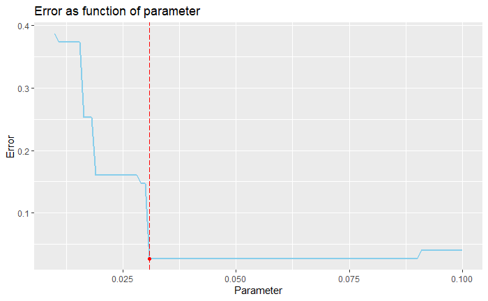

```r
# Gaussian kernel
gaussian_kern <- function(.ep = .05,
                          .dist_matrix,
                          .train_response2,
                          .inv_sigma = sqrt(.5),
                          .alpha = 2){
  kern_fun <- function(x, id, D){
    tem0 <- as.matrix(exp(-(x*D)^(.alpha/2)*.inv_sigma^.alpha))
    y_hat <- map_dfc(.x = 1:ncol(tem0),
                     .f = (\(x_) tibble("{x_}" := tapply(tem0[, x_],
                                                         INDEX = .train_response2[.dist_matrix$id_shuffle != id],
                                                         FUN = sum)))) %>%
      map_chr(.f = (\(x) names(which.max(x))))
    return(mean(y_hat != .train_response2[.dist_matrix$id_shuffle == id]))
  }
  temp <- map2(.x = 1:.dist_matrix$n_cv,
               .y = .dist_matrix$dist,
               .f = ~ kern_fun(x = .ep,
                               id = .x,
                               D = .y))
  return(Reduce("+", temp)/.dist_matrix$n_cv)
}

# Kappa cross-validation error
cost_fun <- function(.ep = .1,
                     .dist_matrix,
                     .kernel_func = NULL,
                     .train_response2,
                     .inv_sigma = sqrt(.5)){
  return(.kernel_func(.ep = .ep,
                     .dist_matrix = .dist_matrix,
                     .train_response2 = .train_response2,
                     .inv_sigma = .inv_sigma))
}

# cross_validation
err_cv <- function(x,
                     .dist_matrix = dis,
                     .kernel_func = gaussian_kern,
                     .train_response2 = df[basic_machines$id2, 5]) {
  res <- cost_fun(.ep = x,
              .dist_matrix = .dist_matrix,
              .kernel_func = .kernel_func,
              .train_response2 = .train_response2)
  return(res)
}

# Optimization
opt_param_grid <- gridOptimizer(obj_fun = err_cv,
                                setParameter = setGridParameter(min_val = 0.01,
                                                                max_val = 0.1,
                                                                n_val = 100,
                                                                figure = TRUE))
```

## 3.4 Fitting parameter

This function gathers the constructed machines and performs grid search algorithm to approximate the smoothing parameter for the aggregation method.

- **Argument**:
  - `train_design` : a matrix or data frame of the training *input data* or the *predicted classes* given by some classifiers.
    - If the *input* data is given, the option `build_machine` must be `TRUE` and all the chosen machines will be constructed using a proportion of the training input (`splits`).
    - If the *predicted classes* are given, the option `build_machine` must be `FALSE` which indicates that no basic machine is constructed, and the paramter is tuned using this matrix of predicted classes directly.
  - `train_response` : a vector of corresponding classes of the `train_design`.
  - `scale_input` : a logical value specifying whether or not to scale the input data before building the basic classifiers. By default, `scale_input = FALSE`.
  - `build_machine`: a logical value specifying whether or not the basic machines should be constructed. It should be `TRUE` if the input data is given to the `train_design`, else it should be `FALSE`. By default, `build_machine = TRUE`.
  - `machines` : a vector of basic machines to be constructed. It must be a subset of {`"knn"`, `"tree"`, `"rf"`, `"logit"`, `"svm"`, `"xgb"`, `"adaboost"`}. By default, `machines = NULL`, and all types of basic machines are built.
  - `splits` : the proportion of training data used to build the basic machines. By default, `splits = .5`.
  - `n_cv` : the number of cross-validation folds used to tune the smoothing parameter.
  - `inv_sig, alp` : the inverse normalized constant $\sigma^{-1}>0$ and the exponent $\alpha >0$ of exponential kernel: $K(x)=e^{-\|x/\sigma\|^{\alpha}}$ for any $x\in\mathbb{R}^d$. By default, `inv_sigma =`$\sqrt{1/2}$ and `alpha = 2` which corresponds to the Gaussian kernel.
  - `kernels` : the kernel function or vector of kernel functions used for the aggregation.
  - `setMachineParam` : an option used to set the values of the parameters of the basic machines. `setBasicParameter` function should be fed to this argument.
  - `setGridParam` : an option used to set the values of the parameters of the grid search algorithm. The `setGridParameter` function should be fed to it.
  - `silent` : a logical value to silent all the messages.
- **Value**:

  This function returns a list of the following objects:
  - `opt_parameters` : the observed optimal parameter.
  - `add_parameters` : other aditional parameters such as scaling options, parameters of kernel functions and the optimization methods used.
  - `basic_machines` : the list of basic machine object.

```r
fit_parameter <- function(train_design,
                          train_response,
                          scale_input = FALSE,
                          build_machine = TRUE,
                          machines = NULL,
                          splits = 0.5,
                          n_cv = 5,
                          inv_sigma = sqrt(.5),
                          alp = 2,
                          kernels = "gaussian",
                          setMachineParam = setBasicParameter(),
                          setGridParam = setGridParameter(),
                          silent = FALSE){
  kernels_lookup <- c("gaussian", "epanechnikov", "biweight", "triweight", "triangular", "naive")
  kernel_real <- kernels %>%
    map_chr(.f = ~ match.arg(.x,
                             kernels_lookup))
  if(build_machine){
     mach2 <- generateMachines(train_input = train_design,
                               train_response = train_response,
                               scale_input = scale_input,
                               machines = machines,
                               splits = splits,
                               basicMachineParam = setMachineParam,
                               silent = silent)
  } else{
    mach2 <- list(predict2 = train_design,
                  models = colnames(train_design),
                  id2 = rep(TRUE, nrow(train_design)),
                  train_data = list(train_response = train_response,
                                    classes = unique(train_response)))
  }
  # distance matrix to compute loss function
  n_ker <- length(kernels)
  id_shuf <- NULL
  dist_all <- dist_matrix(basicMachines = mach2,
                          n_cv = n_cv)

  # Kernel functions
  # ================
  # Gaussian kernel
  gaussian_kernel <- function(.ep = .05,
                              .dist_matrix,
                              .train_response2,
                              .inv_sigma = sqrt(.5),
                              .alpha = 2){
    kern_fun <- function(x, id, D){
      tem0 <- as.matrix(exp(-(x*D)^(.alpha/2)*.inv_sigma^.alpha))
      y_hat <- map_dfc(.x = 1:ncol(tem0),
                       .f = (\(x_) tibble("{x_}" := tapply(tem0[, x_],
                                                           INDEX = .train_response2[.dist_matrix$id_shuffle != id],
                                                           FUN = sum)))) %>%
        map_chr(.f = (\(x) names(which.max(x))))
      return(mean(y_hat != .train_response2[.dist_matrix$id_shuffle == id]))
    }
    temp <- map2(.x = 1:.dist_matrix$n_cv,
                 .y = .dist_matrix$dist,
                 .f = ~ kern_fun(x = .ep,
                                 id = .x,
                                 D = .y))
    return(Reduce("+", temp)/.dist_matrix$n_cv)
  }

  # Epanechnikov
  epanechnikov_kernel <- function(.ep = .05,
                                  .dist_matrix,
                                  .train_response2){
    kern_fun <- function(x, id, D){
      tem0 <- as.matrix(1- x*D)
      tem0[tem0 < 0] = 0
      y_hat <- map_dfc(.x = 1:ncol(tem0),
                       .f = (\(x_) tibble("{x_}" := tapply(tem0[, x_],
                                                           INDEX = .train_response2[.dist_matrix$id_shuffle != id],
                                                           FUN = sum)))) %>%
        map_chr(.f = (\(x) names(which.max(x))))
      return(mean(y_hat != .train_response2[.dist_matrix$id_shuffle == id]))
    }
    temp <- map2(.x = 1:.dist_matrix$n_cv,
                 .y = .dist_matrix$dist,
                 .f = ~ kern_fun(x = .ep,
                                 id = .x,
                                 D = .y))
    return(Reduce("+", temp)/.dist_matrix$n_cv)
  }

  # Biweight
  biweight_kernel <- function(.ep = .05,
                              .dist_matrix,
                              .train_response2){
  kern_fun <- function(x, id, D){
    tem0 <- as.matrix(1- x*D)
    tem0[tem0 < 0] = 0
    y_hat <- map_dfc(.x = 1:ncol(tem0),
                       .f = (\(x_) tibble("{x_}" := tapply(tem0[, x_],
                                                           INDEX = .train_response2[.dist_matrix$id_shuffle != id],
                                                           FUN = sum)))) %>%
        map_chr(.f = (\(x) names(which.max(x))))
      return(mean(y_hat != .train_response2[.dist_matrix$id_shuffle == id]))
    }
    temp <- map2(.x = 1:.dist_matrix$n_cv,
                 .y = .dist_matrix$dist,
                 .f = ~ kern_fun(x = .ep,
                                 id = .x,
                                 D = .y))
    return(Reduce("+", temp)/.dist_matrix$n_cv)
  }

  # Triweight
  triweight_kernel <- function(.ep = .05,
                               .dist_matrix,
                               .train_response2){
  kern_fun <- function(x, id, D){
    tem0 <- as.matrix(1- x*D)
    tem0[tem0 < 0] = 0
    y_hat <- map_dfc(.x = 1:ncol(tem0),
                       .f = (\(x_) tibble("{x_}" := tapply(tem0[, x_],
                                                           INDEX = .train_response2[.dist_matrix$id_shuffle != id],
                                                           FUN = sum)))) %>%
        map_chr(.f = (\(x) names(which.max(x))))
      return(mean(y_hat != .train_response2[.dist_matrix$id_shuffle == id]))
    }
    temp <- map2(.x = 1:.dist_matrix$n_cv,
                 .y = .dist_matrix$dist,
                 .f = ~ kern_fun(x = .ep,
                                 id = .x,
                                 D = .y))
    return(Reduce("+", temp)/.dist_matrix$n_cv)
  }

  # Triangular
  triangular_kernel <- function(.ep = .05,
                                .dist_matrix,
                                .train_response2){
  kern_fun <- function(x, id, D){
    tem0 <- as.matrix(1- x*D)
    tem0[tem0 < 0] <- 0
    y_hat <- map_dfc(.x = 1:ncol(tem0),
                       .f = (\(x_) tibble("{x_}" := tapply(tem0[, x_],
                                                           INDEX = .train_response2[.dist_matrix$id_shuffle != id],
                                                           FUN = sum)))) %>%
        map_chr(.f = (\(x) names(which.max(x))))
      return(mean(y_hat != .train_response2[.dist_matrix$id_shuffle == id]))
    }
    temp <- map2(.x = 1:.dist_matrix$n_cv,
                 .y = .dist_matrix$dist,
                 .f = ~ kern_fun(x = .ep,
                                 id = .x,
                                 D = .y))
    return(Reduce("+", temp)/.dist_matrix$n_cv)
  }

  # error function
  error_cv <- function(x,
                       .dist_matrix = NULL,
                       .kernel_func = NULL,
                       .train_response2 = NULL){
    res <- .kernel_func(.ep = x,
                        .dist_matrix = .dist_matrix,
                        .train_response2 = .train_response2)
    return(res/n_cv)
  }

  # list of kernel functions
  list_funs <- list(gaussian = gaussian_kernel,
                    epanechnikov = epanechnikov_kernel,
                    biweight = biweight_kernel,
                    triweight = triweight_kernel,
                    triangular = triangular_kernel,
                    naive = epanechnikov_kernel)

  # error for all kernel functions
  error_func <- kernel_real %>%
    map(.f = ~ (\(x) error_cv(x,
                              .dist_matrix = dist_all,
                              .kernel_func = list_funs[[.x]],
                              .train_response2 = train_response[mach2$id2])))
  names(error_func) <- kernel_real

  # Optimization
  parameters <- map(.x = kernel_real,
                    .f = ~ gridOptimizer(obj_fun = error_func[[.x]],
                                         setParameter = setGridParam,
                                         naive = .x == "naive",
                                         silent = silent,
                                         ker = .x))
  names(parameters) <- kernel_real
  return(list(opt_parameters = parameters,
              add_parameters = list(scale_input = scale_input,
                                    inv_sigma = inv_sigma,
                                    alp = alp),
              basic_machines = mach2))
}
```

```
* Building basic machines ...
    ~ Progress: ... 33% ... 67% ... 100%
* Grid search for gaussian kernel...
    ~ observed parameter : 0.1640909
* Grid search for biweight kernel...
    ~ observed parameter : 0.09764646
* Grid search for triangular kernel...
    ~ observed parameter : 0.09764646
```

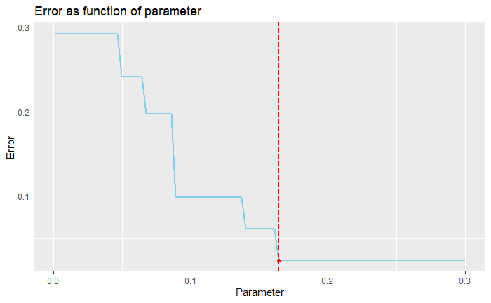

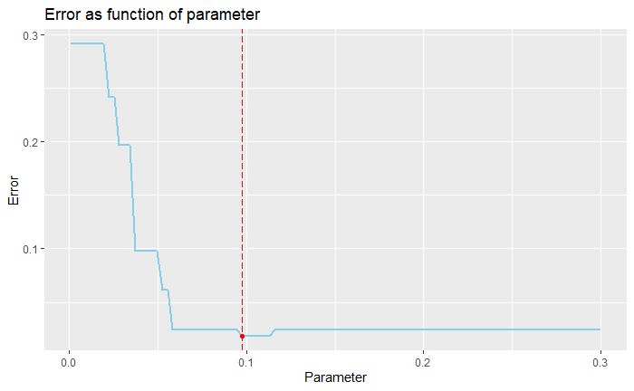

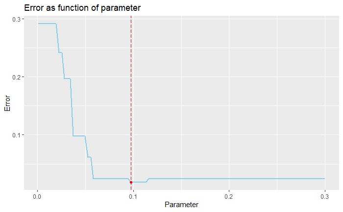

```r
df <- iris
train <- logical(nrow(df))
train[sample(length(train), floor(0.75*nrow(df)))] <- TRUE

param <- fit_parameter(train_design = df[train, 1:4],
                       train_response = df$Species[train],
                       machines = c("knn", "rf", "xgb"),
                       splits = .5,
                       n_cv = 3,
                       kernels = c("gaussian","biweight", "naive", "triangular"),
                       setMachineParam = setBasicParameter(k = 2:5,
                                                           ntree = c(1,3,5)*100,
                                                           nrounds_xgb = c(1,3,5)*100),
                       setGridParam = setGridParameter(min_val = 0.001,
                                                      max_val = 0.3,
                                                      n_val = 100),
                       silent = FALSE)
```

```r
param$opt_parameters %>%
  map_dfc(.f = ~ .x$opt_param) %>%
  print
```

| gaussian | biweight | naive | triangular |
| --- | --- | --- | --- |
| 0.1640909 | 0.09764646 | NA | 0.09764646 |

# 4 Prediction

The smoothing parameter obtained from the previous section can be used to make the final predictions.

## 4.1 Kernel functions

Several types of kernel functions used for the aggregation are defined in this section.

- **Argument**:
  - `.h` : the value of the parameter used.
  - `.y2` : the vector of response variable of the second part $\mathcal{D}_{\ell}$ of the training data, which is used for the aggregation.
  - `.distance` : the distance matrix object obtained from `dist_matrix` function.
  - `.kern` : the string specifying the kernel function. By default, `.kern = "gaussian"`.
  - `.inv_sig, .alp` : the parameters of exponential kernel function.
- **Value**:

  This function returns the predicted classes of the aggregation method evaluated with the given parameter $h>0$.

```r
kernel_pred <- function(.h,
                        .y2,
                        .distance,
                        .kern = "gaussian",
                        .inv_sig = sqrt(.5),
                        .alp = 2){
  dis <- as.matrix(.distance)
  # Kernel functions
  # ================
  gaussian_kernel <- function(.ep,
                              .inv_sigma = .inv_sig,
                              .alpha = .alp){
    tem0 <- exp(- (.ep*dis)^(.alpha/2)*.inv_sig^.alpha)
    y_hat <- map_dfc(.x = 1:ncol(tem0),
                     .f = (\(x_) tibble("{x_}" := tapply(tem0[, x_],
                                                           INDEX = .y2,
                                                           FUN = sum)))) %>%
        map_chr(.f = (\(x) names(which.max(x))))
    return(as.vector(y_hat))
  }

  # Epanechnikov
  epanechnikov_kernel <- function(.ep){
    tem0 <- 1- .ep*dis
    tem0[tem0 < 0] = 0
    y_hat <- map_dfc(.x = 1:ncol(tem0),
                     .f = (\(x_) tibble("{x_}" := tapply(tem0[, x_],
                                                           INDEX = .y2,
                                                           FUN = sum)))) %>%
        map_chr(.f = (\(x) names(which.max(x))))
    return(as.vector(y_hat))
  }
  # Biweight
  biweight_kernel <- function(.ep){
    tem0 <- 1- .ep*dis
    tem0[tem0 < 0] = 0
    y_hat <- map_dfc(.x = 1:ncol(tem0),
                     .f = (\(x_) tibble("{x_}" := tapply(tem0[, x_],
                                                           INDEX = .y2,
                                                           FUN = sum)))) %>%
        map_chr(.f = (\(x) names(which.max(x))))
    return(as.vector(y_hat))
  }

  # Triweight
  triweight_kernel <- function(.ep){
    tem0 <- 1- .ep*dis
    tem0[tem0 < 0] = 0
    y_hat <- map_dfc(.x = 1:ncol(tem0),
                     .f = (\(x_) tibble("{x_}" := tapply(tem0[, x_],
                                                           INDEX = .y2,
                                                           FUN = sum)))) %>%
        map_chr(.f = (\(x) names(which.max(x))))
    return(as.vector(y_hat))
  }

  # Triangular
  triangular_kernel <- function(.ep){
    tem0 <- 1- .ep*dis
    tem0[tem0 < 0] <- 0
    y_hat <- map_dfc(.x = 1:ncol(tem0),
                     .f = (\(x_) tibble("{x_}" := tapply(tem0[, x_],
                                                           INDEX = .y2,
                                                           FUN = sum)))) %>%
        map_chr(.f = (\(x) names(which.max(x))))
    return(as.vector(y_hat))
  }
  # Naive
  naive_kernel <- function(.ep = NULL){
      y_hat <- map_dfc(.x = 1:ncol(dis),
                       .f = (\(x_) tibble("{x_}" := tapply(dis[, x_] == 0,
                                                           INDEX = .y2,
                                                           FUN = sum)))) %>%
        map_chr(.f = (\(x) names(which.max(x))))
    return(as.vector(y_hat))
  }
  # Prediction
  kernel_list <- list(gaussian = gaussian_kernel,
                      epanechnikov = epanechnikov_kernel,
                      biweight = biweight_kernel,
                      triweight = triweight_kernel,
                      triangular = triangular_kernel,
                      naive = naive_kernel)
  res <- tibble(as.vector(kernel_list[[.kern]](.ep = .h)))
  names(res) <- .kern
  return(res)
}
```

## 4.2 Functions: `predict_agg`

This function takes the `fit_parameter` object (which contains the observed optimal parameter) to predict a new data.

- **Argument**:
  - `fitted_models` : the object obtained from `fit_parameter` function.
  - `new_data` : the new testing data to be predicted.
  - `test_response` : the actual classes of testing data. It is optional. If it is given, the misclassification and accuracy evaluated on the testing data are also computed. By default, `test_response = NULL`.
  - `naive` : logical value specifying whether `"naive"` kernel is used or not.
- **Value**:

  This function returns a *list* of the following objects:
  - `fitted_aggregate` : the predictions by the aggregation methods.
  - `fitted_machine` : the predictions given by all the basic machines.
  - `mis_error`, `accuracy` : the misclassification error and accuracy computed only if the `test_reponse` argument is not `NULL`.

```r
# Prediction
predict_agg <- function(fitted_models,
                        new_data,
                        test_response = NULL,
                        naive = FALSE){
  opt_param <- fitted_models$opt_parameters
  add_param <- fitted_models$add_parameters
  basic_mach <- fitted_models$basic_machines
  kern0 <- names(opt_param)
  new_data_ <- new_data
  # if basic machines are built
  if(is.list(basic_mach$models)){
    mat_input <- as.matrix(basic_mach$train_data$train_input)
    if(add_param$scale_input){
      new_data_ <- scale(new_data,
                         center = basic_mach$scale_min,
                         scale = basic_mach$scale_max - basic_mach$scale_min)
    }
    if(is.matrix(new_data_)){
      mat_test <- new_data_
      df_test <- as_tibble(new_data_)
    } else {
      mat_test <- as.matrix(new_data_)
      df_test <- new_data_
    }

    # Prediction test by basic machines
    built_models <- basic_mach$models
    pred_test <- function(meth){
      if(meth == "knn"){
        pre <- 1:length(built_models[[meth]]) %>%
          map_dfc(.f = (\(k) tibble('{{k}}' := FNN::knn(train = mat_input[!basic_mach$id2,],
                                                        test = mat_test,
                                                        cl = basic_mach$train_data$train_response[!basic_mach$id2],
                                                        k = built_models[[meth]][[k]]))))
      }
      if(meth == "xgb"){
        pre <- 1:length(built_models[[meth]]) %>%
          map_dfc(.f = (\(k) tibble('{{k}}' := as.vector(basic_mach$train_data$classes[predict(built_models[[meth]][[k]], mat_test)]))))
      }
      if(meth == "adaboost"){
        pre <- 1:length(built_models[[meth]]) %>%
          map_dfc(.f = (\(k) tibble('{{k}}' := as.vector(predict.boosting(built_models[[meth]][[k]], as.data.frame(df_test))$class))))
      }
      if(!(meth %in% c("xgb", "knn", "adaboost"))){
        pre <- 1:length(built_models[[meth]]) %>%
          map_dfc(.f = (\(k) tibble('{{k}}' := as.vector(predict(built_models[[meth]][[k]], df_test, type = 'class')))))
      }
      colnames(pre) <- names(built_models[[meth]])
      return(pre)
    }
    pred_test_all <- names(built_models) %>%
      map_dfc(.f = pred_test)
  } else{
    pred_test_all <- new_data_
  }
  pred_test0 <- pred_test_all
  # Prediction train2
  pred_train_all <- basic_mach$predict2
  colnames(pred_test_all) <- colnames(pred_train_all)
  d_train <- dim(pred_train_all)
  d_test <- dim(pred_test_all)
  pred_test_mat <- as.matrix(pred_test_all)
  pred_train_mat <- as.matrix(pred_train_all)
  # Distance matrix
  dists <- 1:d_test[1] %>%
      map_dfc(.f = (\(id) tibble('{{id}}' := rowSums(sweep(pred_train_mat, 2, pred_test_mat[id,], FUN = "!=")))))
  prediction <- 1:length(kern0) %>%
    map_dfc(.f = ~ kernel_pred(.h = opt_param[[kern0[.x]]]$opt_param,
                               .y2 = basic_mach$train_data$train_response[basic_mach$id2],
                               .distance = dists,
                               .kern = kern0[.x],
                               .inv_sig = add_param$inv_sigma,
                               .alp = add_param$alp))
  if(is.null(test_response)){
    return(list(fitted_aggregate = prediction,
           fitted_machine = pred_test_all))
  } else{
    error <- cbind(pred_test_all, prediction) %>%
      dplyr::mutate(y_test = test_response) %>%
      dplyr::summarise_all(.funs = ~ (. != y_test)) %>%
      dplyr::select(-y_test) %>%
      dplyr::summarise_all(.funs = ~ mean(.))
    return(list(fitted_aggregate = prediction,
                fitted_machine = pred_test0,
                mis_error = error,
                accuracy = 1 - error))
  }
}
```

> **Example.5** Aggregation on `iris` dataset.

```r
pred <- predict_agg(param,
            new_data = df[!train, 1:4],
            test_response = df$Species[!train])
pred$mis_error
```

| knn1 | knn2 | knn3 | knn4 | rf1 | rf2 | rf3 | xgb1 | xgb2 | xgb3 | gaussian | biweight | naive | triangular |
| --- | --- | --- | --- | --- | --- | --- | --- | --- | --- | --- | --- | --- | --- |
| 0.02631579 | 0.02631579 | 0.02631579 | 0.05263158 | 0.05263158 | 0.05263158 | 0.05263158 | 0.05263158 | 0.05263158 | 0.05263158 | 0.05263158 | 0.05263158 | 0.05263158 | 0.05263158 |

# 5 Function : `KernelAggClassifier`

This function puts together all the functions above and provides the desire result of the kernel-based combined classifiers.

- **Argument**:
  - `train_design` : a matrix or data frame of the training *input data* or the *predicted classes* given by some classifiers.
    - If the *input* data is given, the option `build_machine` must be `TRUE` and all the chosen machines will be constructed using a proportion of the training input (`splits`).
    - If the *predicted classes* are given, the option `build_machine` must be `FALSE` which indicates that no basic machine is constructed, and the paramter is tuned using this matrix of predicted classes directly.
  - `train_response` : a vector of corresponding classes of the `train_design`.
  - `test_response` : the actual classes of testing data. It is optional. If it is given, the misclassification and accuracy evaluated on the testing data are also computed. By default, `test_response = NULL`.
  - `scale_input` : a logical value specifying whether or not to scale the input data before building the basic classifiers. By default, `scale_input = FALSE`.
  - `build_machine`: a logical value specifying whether or not the basic machines should be constructed. It should be `TRUE` if the input data is given to the `train_design`, else it should be `FALSE`. By default, `build_machine = TRUE`.
  - `machines` : a vector of basic machines to be constructed. It must be a subset of {`"knn"`, `"tree"`, `"rf"`, `"logit"`, `"svm"`, `"xgb"`, `"adaboost"`}. By default, `machines = NULL`, and all types of basic machines are built.
  - `splits` : the proportion of training data used to build the basic machines. By default, `splits = .5`.
  - `n_cv` : the number of cross-validation folds used to tune the smoothing parameter.
  - `inv_sig, alp` : the inverse normalized constant $\sigma^{-1}>0$ and the exponent $\alpha>0$ of exponential kernel: $K(x)=e^{-\|x/\sigma\|^{\alpha}}$ for any $x\in\mathbb{R}^d$. By default, `inv_sigma =`$\sqrt{1/2}$ and `alpha = 2` which corresponds to the Gaussian kernel.
  - `kernels` : the kernel function or vector of kernel functions used for the aggregation.
  - `setMachineParam` : an option used to set the values of the parameters of the basic machines. `setBasicParameter` function should be fed to this argument.
  - `setGridParam` : an option used to set the values of the parameters of the grid search algorithm. The `setGridParameter` function should be fed to it.
  - `silent` : a logical value to silent all the messages.
- **Value**:

  This function returns a *list* of the following objects:
  - `fitted_aggregate` : the predictions of the testing data given by the aggregation methods correpsonding to all the kernel functions.
  - `fitted_machine` : the predictions of the testing data given by the basic machines.
  - `pred_train2` : the predictions of the second part of the training data $\mathcal{D}_{\ell}$ by all the basic machines.
  - `opt_parameter` : the observed optimal smoothing parameters.
  - `mis_class` : the misclassification error evaluated on the testing data if the testing response variable is given.
  - `accuracy` : the accuracy ($1-$`mis_class`) evaluated on the testing data if the testing response variable is given.
  - `kernels` : the kernel functions used.

```r
KernelAggClassifier <- function(train_design,
                           train_response,
                           test_design,
                           test_response = NULL,
                           scale_input = FALSE,
                           build_machine = TRUE,
                           machines = NULL,
                           splits = 0.5,
                           n_cv = 5,
                           inv_sigma = sqrt(.5),
                           alp = 2,
                           kernels = "gaussian",
                           setMachineParam = setBasicParameter(),
                           setGridParam = setGridParameter(),
                           silent = FALSE){
  # build machines + tune parameter
  fit_mod <- fit_parameter(train_design = train_design,
                           train_response = train_response,
                           scale_input = scale_input,
                           build_machine = build_machine,
                           machines = machines,
                           splits = splits,
                           n_cv = n_cv,
                           inv_sigma = inv_sigma,
                           alp = alp,
                           kernels = kernels,
                           setMachineParam = setMachineParam,
                           setGridParam = setGridParam,
                           silent = silent)
  # prediction
  pred <- predict_agg(fitted_models = fit_mod,
                      new_data = test_design,
                      test_response = test_response)
  return(list(fitted_aggregate = pred$fitted_aggregate,
              fitted_machine = pred$fitted_machine,
              pred_train2 = fit_mod$basic_machines$predict2,
              opt_parameter = fit_mod$opt_parameters,
              mis_class = pred$mis_error,
              accuracy = pred$accuracy,
              kernels = kernels,
              ind_D2 = fit_mod$basic_machines$id2))
}
```

> **Example.6** A complete aggregation is implemented on `iris` dataset. Four types of basic machines, and four different kernel functions are used.

```
* Building basic machines ...
    ~ Progress: ... 25% ... 50% ... 75% ... 100%
* Grid search for gaussian kernel...
    ~ observed parameter : 0.09596768
* Grid search for epanechnikov kernel...
    ~ observed parameter : 0.04041323
* Grid search for triangular kernel...
    ~ observed parameter : 0.04041323
```

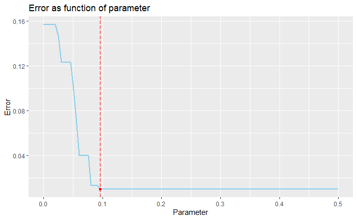

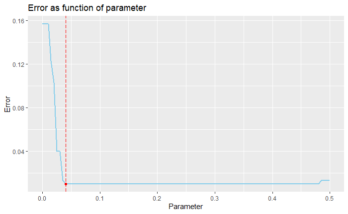

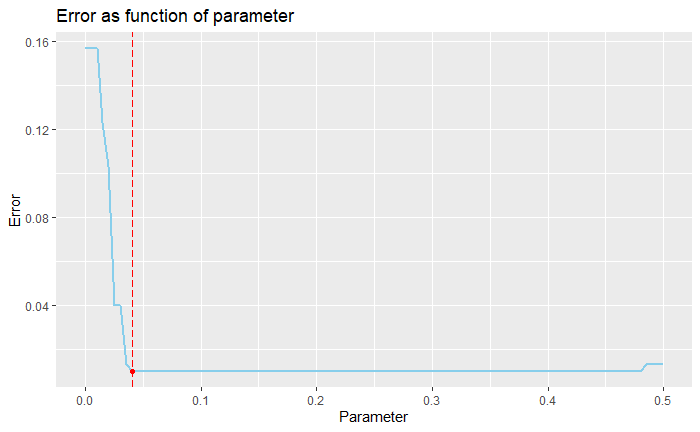

```r
df1 <- iris
train <- logical(nrow(df1))
train[sample(length(train), floor(0.8*nrow(df1)))] <- TRUE

agg <- KernelAggClassifier(train_design = df1[train, 1:4],
                      train_response = df1$Species[train],
                      test_design = df1[!train, 1:4],
                      test_response = df1$Species[!train],
                      machines = c("knn", "rf", "xgb", "svm"),
                      splits = .5,
                      n_cv = 5,
                      kernels = c("gaussian","naive", "epan", "triang"),
                      setMachineParam = setBasicParameter(k = 2:5,
                                                          ntree = 1:3*100,
                                                          nrounds_xgb = 1:3*100),
                      setGridParam = setGridParameter(n_val = 100),
                      silent = FALSE)
```

```r
  agg$accuracy
```

| knn1 | knn2 | knn3 | knn4 | rf1 | rf2 | rf3 | xgb1 | xgb2 | xgb3 | svm1 | gaussian | naive | epanechnikov | triangular |
| --- | --- | --- | --- | --- | --- | --- | --- | --- | --- | --- | --- | --- | --- | --- |
| 0.9666667 | 0.9666667 | 0.9 | 0.9666667 | 0.9333333 | 0.9333333 | 0.9333333 | 0.9666667 | 0.9666667 | 0.9666667 | 0.9333333 | 0.9666667 | 0.9 | 0.9666667 | 0.9666667 |

# References

- [Mojirsheibani (1999)](https://www.tandfonline.com/doi/abs/10.1080/01621459.1999.10474154?journalCode=uasa20) for classification
- [Mojirsheibani (2000)](https://www.sciencedirect.com/science/article/pii/S0167715200000249) for classification
- [Mojirsheibani and Kong (2016)](https://www.sciencedirect.com/science/article/pii/S0167715216301304) for classification
- [Biau et al. (2016)](https://www.sciencedirect.com/science/article/pii/S0047259X15000950) for regression
- [Has (2021)](https://hal.archives-ouvertes.fr/hal-02884333v5) for regression for regression
- [Fischer and Mougeot (2019)](https://www.sciencedirect.com/science/article/pii/S0378375818302349) for both
- …
- [dplyr videos](https://www.youtube.com/hashtag/dplyr)
- [ggplot2 video tutorial](https://www.youtube.com/hashtag/ggplot2)
- [R for data science](https://r4ds.had.co.nz/)

> 📖 Read also [GradientCOBRARegressor](https://hassothea.github.io/files/CodesPhD/KernelAggReg.html) and [MixCOBRARegressor](https://hassothea.github.io/files/CodesPhD/MixCobraReg.html) methods.